# Subplot

Te permite generar subgráficos de acuerdo a tus necesidades. Esto lo hace a través de una matriz de gráficos

```python
#importando librerias
import matplotlib as mtl
import matplotlib.pyplot as plt
import numpy as np
```

```python
x = np.linspace(0,5,10)
y = x**2
```

> Ahora imaginemos que queremos 2 gráficas. Podemos definirlo con `subplot()`.

```
subplot(filas,columnas,index)
```

Donde:

- `filas` es el número de filas que tendrá la gráfica.
- `columnas` es el número de columnas que tendrá la gráfica.
- `index` es el indice que tendra la gráfica con respecto de las filas y columnas.

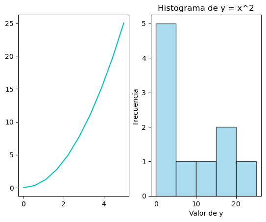

```python
#Subplots
#1 fila y 2 columnas, me va a crear 2 indices
#Para el indice 1 o gráfica 1
plt.subplot(1,2,1)
plt.plot(x,y,'c-')
#Para el indice 2 o gráfica 2
plt.subplot(1,2,2)
#Para que se vea adecuado el histograma
plt.hist(y, bins=5, color='skyblue', edgecolor='black', alpha=0.7)
#plt.hist(y, bins=10, color='lightcoral', edgecolor='darkred', alpha=0.75)
plt.title('Histograma de y = x^2')
plt.xlabel('Valor de y')
plt.ylabel('Frecuencia')
#Vamos a gráficar
plt.show()
```

# De esta manera:

Tengo 1 fila con 2 columnas.

# Explicación:

En la gráfica 1, tenemos 2 gráficas dentro del mismo subplot.

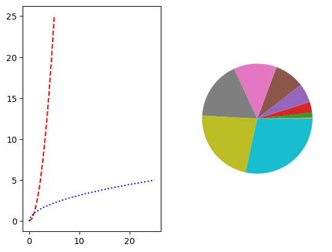

```python
#Grafica 1
plt.subplot(1,2,1)
plt.plot(x,y,'r--')
plt.plot(y,x,'b:')

#Grafica 2
plt.subplot(1,2,2)
plt.pie(y)

#Desplegando graficas
plt.show()
```

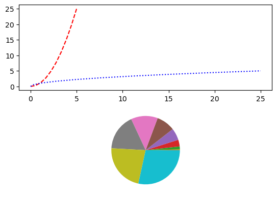

```python
#Graficando 2 filas, 1 columna
#Grafica 1
plt.subplot(2,1,1)
plt.plot(x,y,'r--')
plt.plot(y,x,'b:')

#Grafica 2
plt.subplot(2,1,2)
plt.pie(y)

#Desplegando graficas
plt.show()
```

# Explicación:

En el subplot anterior configuramos 2 filas, 1 columna. De ahí procedemos a hacer el despliegue.

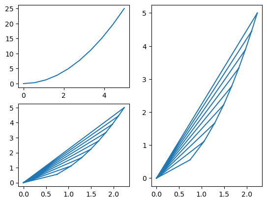

```python
#Graficando de diferente manera
z=x**(1/2)
#Grafica 1
plt.subplot(2,2,1)
plt.plot(x,y, '')
#Grafica 2
plt.subplot(1,2,2)
plt.triplot(z,x)
#Grafica 3
plt.subplot(2,2,3)
plt.triplot(z,x)
#Despliegue
plt.show()
```

# Apuntes extras:

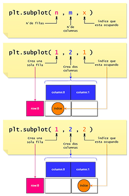

# Referencias:

- Subplot o subplots
- [Matplot-pyplot-Subplot](https://matplotlib.org/stable/api/_as_gen/matplotlib.pyplot.subplot.html)